# Applied-Statistics-Project Proposal

ShuoliChen

2020/5/22

## Data Description

Here we have a data set which is the daily closing price of the New York stock exchange(NYSE). It includes the data of NYSE from February 7, 1984 to July 16, 2012. Closing price is the final price at which it trades during regular market hours on any given day. It is considered the most accurate valuation of a stock or other security until trading resumes on the next trading day.

## EDA & Research topic

First we plot the data with timing diagram:

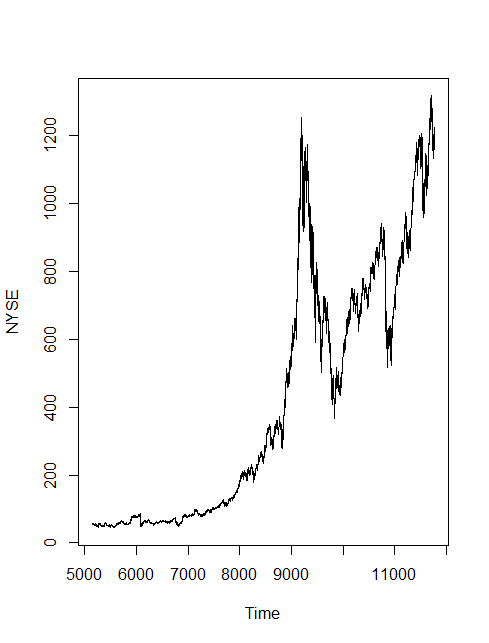

The basic information of the data is:

```
> stat.desc(NYSE)
                        x
nbr.val      6.625000e+03
nbr.null     0.000000e+00
nbr.na       0.000000e+00
min          4.442000e+01
max          1.316946e+03
range        1.272526e+03
sum          2.748025e+06
median       2.653700e+02
mean         4.147963e+02
SE.mean      4.523171e+00
CI.mean.0.95 8.866873e+00
var          1.355414e+05
std.dev      3.681595e+02
coef.var     8.875669e-01
```

According to the plot, we prefer that the data is not stationary and is not white noise. We deal it with experiment：

$\mathbf{1}$.Make the data stationary with curve-fittin. We use $e^{a_0+a_1x+a_2x^2}$ to fit the data, and get the coefficients:

```
> fit <- lm(log(NYSE) ~ x+I(x^2))
> fit
Call:
lm(formula = log(NYSE) ~ x + I(x^2))
Coefficients:
(Intercept)            x       I(x^2)
  3.482e+00    6.837e-04   -1.793e-08
```

Now we check if the transformed data is stationary:

```
> adf.test(NYSE11)
Augmented Dickey-Fuller Test
data:  NYSE11
Dickey-Fuller = -2.1416, Lag order = 18, p-value = 0.5184
alternative hypothesis: stationary
```

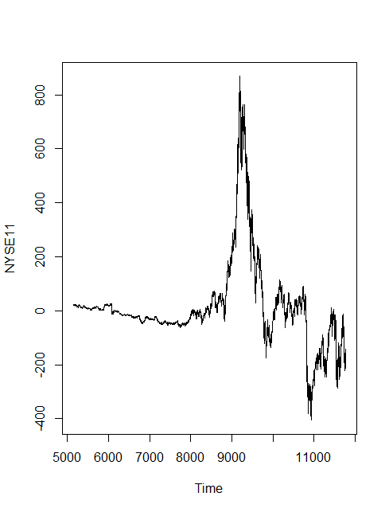

$\mathbf{2}$.White noise test. We conduct Ljung-Box white noise test to the transformed data:

```
> Box.test(NYSE11, type="Ljung-Box")
    Box-Ljung test
data:  NYSE11
X-squared = 6603, df = 1, p-value < 2.2e-16
```

We can see that the transformed data is not white noise. So it deserves further exploring. Obviously, this is a heteroscedastic data, our aim is to find a proper time series model for this data with its heteroscedasticity captured.

Why heteroscedasticity so serious? In statistics, a collection of random variables is heteroscedastic if there are sub-populations that have different variabilities from others. Here "variability" could be quantified by the variance or any other measure of statistical dispersion. The existence of heteroscedasticity is a major concern in the application of regression analysis. Essentially, wherever there is heteroskedasticity, observations do not conform to a linear pattern. Instead, they tend to cluster. Therefore, if statistical models that assume constant variance are used on this data, then the conclusions and predictive value one can draw from the model will not be reliable.

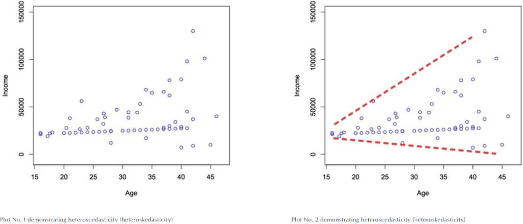

## To do

We try to find the pattern of the closing price of NYSE all these years to seize the rule of economic trend of New York, the tool we try to use is time series. The difficulty of the project is that the data is stable at the first part, but fluctuates drastically at the second part. To capture this feature of the data, a suitable model strategy would be necessary.

Generalized AutoRegressive Conditional Heteroskedasticity (GARCH) is a statistical model used in analyzing time-series data where the variance error is believed to be serially autocorrelated. GARCH models assume that the variance of the error term follows an autoregressive moving average process. It is a statistical modeling technique used to help predict the volatility of returns on financial assets.

\begin{aligned} &y_{t}=x_{t}^{\prime} b+\epsilon_{t}\\ &\epsilon_{t} | \psi_{t-1} \sim \mathcal{N}\left(0, \sigma_{t}^{2}\right)\\ &\sigma_{t}^{2}=\omega+\alpha_{1} \epsilon_{t-1}^{2}+\cdots+\alpha_{q} \epsilon_{t-q}^{2}+\beta_{1} \sigma_{t-1}^{2}+\cdots+\beta_{p} \sigma_{t-p}^{2}=\omega+\sum_{i=1}^{q} \alpha_{i} \epsilon_{t-i}^{2}+\sum_{i=1}^{p} \beta_{i} \sigma_{t-i}^{2} \end{aligned}

Many variations of GARCH have emerged. These include Nonlinear (NGARCH), which addresses correlation and observed "volatility clustering" of returns, and Integrated GARCH (IGARCH), which restricts the volatility parameter. All the GARCH model variations seek to incorporate the direction, positive or negative, of returns in addition to the magnitude (addressed in the original model). Each derivation of GARCH can be used to accommodate the specific qualities of the stock, industry, or economic data. Our goal is to find the most suitable model for this specific NYSE data.